# MATH5741M: Statistical Theory and Methods

Benjamin Thorpe

2021-12-14

Benjamin Thorpe (b.thorpe@leeds.ac.uk)  
Tuesday December 14, 2021

# 2 Exploratory Data Analysis

Before any statistical modelling, we should always explore and summarise our data. In other words, once we observe a sample, we want to know what it looks like.

## 2.1 Numerical summaries

Suppose that our data are realisations, $\{x_{1}, x_{2}, \ldots, x_{n}\}$, of a random sample from the distribution of some random variable $X$. It makes sense to calculate summaries that measure properties such as spread and symmetry of the data, since these might give us some insight into the spread and symmetry of the distribution from which the data were sampled. If the data are very asymmetrical, then we might doubt that a normal distribution (which is symmetrical) would be an appropriate model for $X$.

### 2.1.1 Moments

**Definition 2.1** Given data $\{x_{1}, x_{2}, \ldots, x_{n}\}$ and any $\alpha \in \mathbb{R}$, the **$k$-th sample moment about $\alpha$** is
$$m_k(\alpha) = \frac{1}{n} \displaystyle\sum_{i=1}^{n} (x_i - \alpha)^k \quad \text{for } k \in \mathbb{N}.$$

Sample moments aren’t so easy to interpret (and I don’t expect you to remember the formula), but we can use them to calculate quantities that are more useful in practice:

**Definition 2.2** Given data $\{x_{1}, x_{2}, \ldots, x_{n}\}$, the **sample mean** is
$$\overline{x} = m_{1}(0) = \frac{1}{n}\sum_{i = 1}^{n}x_{i} \;.$$
The **sample variance** is
$$s^{2} = \frac{n}{n - 1}m_{2}(\overline{x}) = \frac{1}{n-1}\sum_{i = 1}^{n}(x_{i} - \overline{x})^{2} \;.$$
The **sample standard deviation** is
$$s = \sqrt{s^2}\;.$$
The **coefficient of skewness** is
$$g_1 = \frac{m_3(\overline{x})}{s^3} = \frac{\frac{1}{n}\sum_{i=1}^n(x_{i} - \overline{x})^3}{s^3}\;.$$

**Example 2.1 (hospital stay, continued)** Recall our hospital stay example from the previous chapter. Suppose that we randomly select $10$ patients and observe the number of days they spend in hospital:
$$\{x_{1}, \ldots, x_{10}\} = \{3, 4, 5, 3.5, 6, 7, 12, 19.5, 10, 30\}$$
The sample mean is
$$\begin{eqnarray*}
\overline{x} = \frac{1}{10}\sum_{i = 1}^{10}(x_{i} - 0)^{1} = \frac{1}{10}(3 + 4 + \cdots + 30) = 10 \text{ days}.\end{eqnarray*}$$
The sample variance is
$$\begin{eqnarray*} s^{2} &=& \frac{1}{10-1}\sum_{i = 1}^{10}(x_{i} - 10)^{2} = \frac{1}{9}\left[ (3 - 10)^{2} + \cdots + (30 - 10)^{2} \right] \approx 74.6.\end{eqnarray*}$$
Taking the square root, the sample standard deviation is $s \approx 8.6$ days.
$$\begin{eqnarray*} \frac{1}{10}\sum_{i=1}^{10}(x_{i} - \overline{x})^{3} &=& \frac{1}{10}\left[ (3 - 10)^{3} + \cdots + (30 - 10)^{3} \right] \approx 781.6\end{eqnarray*}$$
and therefore
$$g_{1} \approx \frac{781.6}{8.6^3} \approx 1.2.$$
The skew here is positive, so we have a skew to the right. We can see what this means by plotting our data as in Figure 2.1.

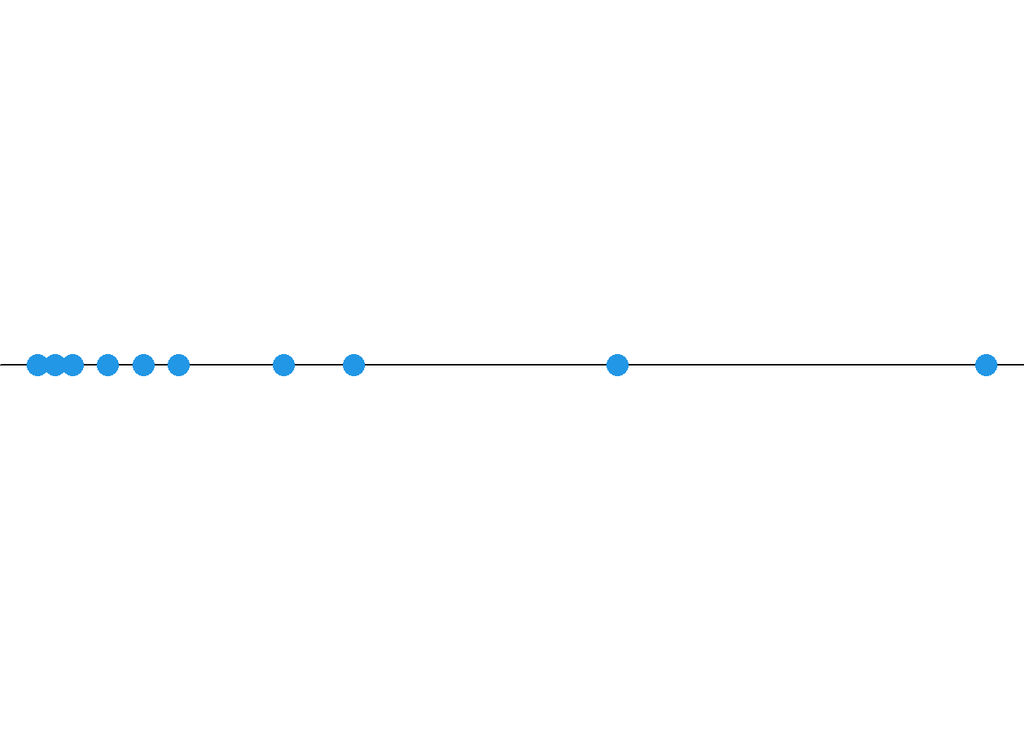

Figure 2.1: A plot of our data, showing its positive skew (with most points clustered to the left).

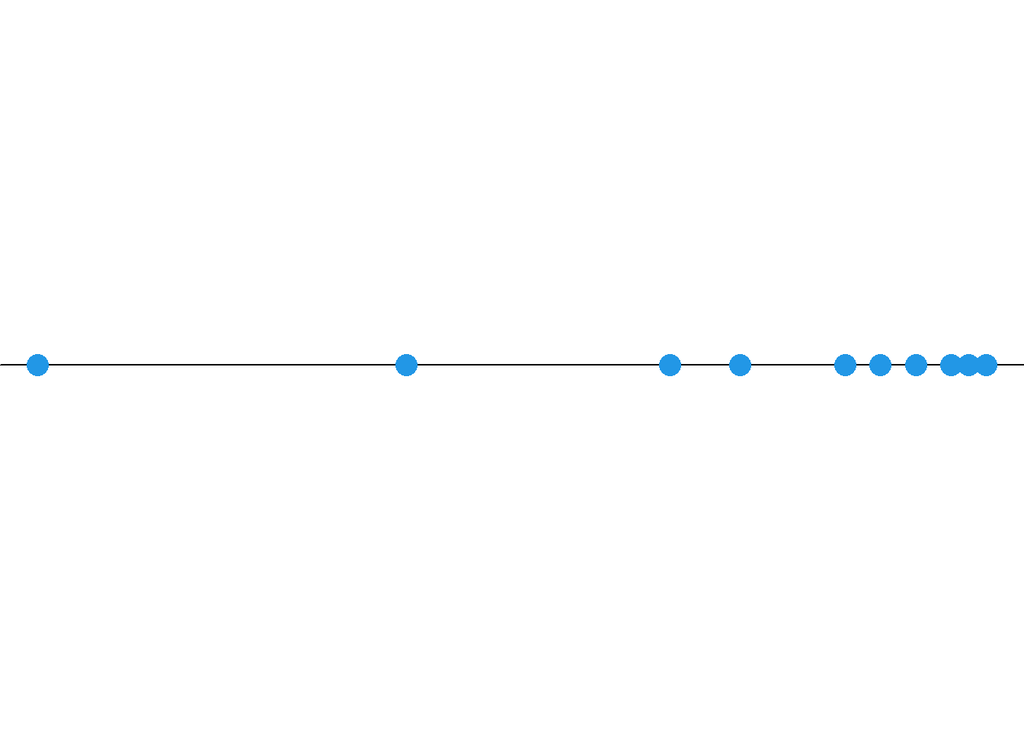

Figure 2.2: A plot of hypothetical negatively skewed data (with most points clustered to the right).

The skew is positive because we have many short hospital stays clustered to the left, with a few very long stays to the right. Figure 2.2 is an example of what data with a negative skew would look like.

### 2.1.2 Quantiles

So far, we have only looked at summaries based on sample moments. We could also explore our data by calculating summaries based on sample quantiles.

**Definition 2.3** Suppose that we have observed a sample $\{x_{1}, x_{2}, \ldots, x_{n}\}$, and let
$$x_{(1)} , x_{(2)}, \ldots , x_{(n)}$$
be the same sample ordered from smallest to largest, so that $x_{(1)} \le x_{(2)}\le \cdots \le x_{(n)}$. Then these are the **order statistics**.

**Definition 2.4** The $p$-th **sample quantile** (denoted $q_p$), is the smallest $x_{(i)}$ for which at least a proportion $p$ of our observations are $\leq x_{(i)}$.

**Definition 2.5** The **sample median** is $q_{0.5}$. The **lower and upper sample quartiles** are $q_{0.25}$ and $q_{0.75}$, respectively. The **interquartile range (IQR)** is $q_{0.75}-q_{0.25}$. The **range** is $x_{(n)}-x_{(1)}$.

The sample median is the smallest $x_{(i)}$ that is greater than or equal to at least $50\%$ of the sample. Roughly interpreted, IQR is the length of an interval containing the “middle half” of our data. It tells us about the spread of our data.

**Example 2.2 (hospital stay, continued)** Ordering our data, we have
$$x_{(1)}, \ldots, x_{(10)} = 3, 3.5, 4, 5, 6, 7, 10, 12, 19.5, 30.$$
We see that half of the data are less than or equal to $x_{(5)} = 6$, so our sample median is
$$q_{0.5} = x_{(5)} = 6.$$
What is the upper quartile, $q_{0.75}$? Only $70\%$ of the data are $\leq x_{(7)} = 10$, so $x_{(7)}$ is not the upper quartile. But $80\%$ are $\leq x_{(8)} = 12$. Therefore $x_{(8)}$ is the smallest observation which at least $75\%$ of our observations are less than or equal to:
$$q_{0.75} = x_{(8)} = 12.$$
Similarly, $q_{0.25} = 4$.

**Warning:** The results that we have produced here are different to the results we get from R.

```r
x <- c(3, 3.5, 4, 5, 6, 7, 10, 12, 19.5, 30)
quantile(x)
```

```
##    0%   25%   50%   75%  100%
##  3.00  4.25  6.50 11.50 30.00
```

This is because, by default, R uses a different convention for calculating quantiles. For example, the median in this output is defined to be the average of the two middle values in our ordered sample
$$\frac{x_{(5)} + x_{(6)}}{2} = \frac{6 + 7}{2} = 6.5$$
However, we can request R to use our definition of a sample quantile by specifying `type = 1` (the default is `type = 7`):

```r
quantile(x, type = 1)
```

```
##   0%  25%  50%  75% 100%
##    3    4    6   12   30
```

But it doesn’t really matter which we use, as long as we are aware of why we see different numbers and don’t interpret them incorrectly.

**Example 2.3 (hospital stay, continued)** Suppose that we observe the hospital stay of one more patient, $x_{11} = 150$ days, and include this in our sample:
$$x_{(1)}, \ldots, x_{(11)} = 3, 3.5, 4, 5, 6, 7, 10, 12, 19.5, 30, 150.$$
This observation appears to be improbably extreme when compared to the rest of the sample. It might therefore be considered to be an **outlier**. How does it affect our data summaries?

```r
x_old <- c(3, 3.5, 4, 5, 6, 7, 10, 12, 19.5, 30)
x_new <- c(3, 3.5, 4, 5, 6, 7, 10, 12, 19.5, 30, 150)
```

First we calculate the mean and standard deviation for each sample:

```r
mean(x_old); mean(x_new)
```

```
## [1] 10
```

```
## [1] 22.72727
```

```r
sd(x_old); sd(x_new)
```

```
## [1] 8.637772
```

```
## [1] 42.99963
```

The mean has more than doubled just because we added one new observation, and the standard deviation has increased by more than a factor of four. Now let’s calculate some quantiles for each:

```r
quantile(x_old, type = 1)
```

```
##   0%  25%  50%  75% 100%
##    3    4    6   12   30
```

```r
quantile(x_new, type = 1)
```

```
##    0%   25%   50%   75%  100%
##   3.0   4.0   7.0  19.5 150.0
```

The median and quartiles are affected much less. The median has only changed from $6$ to $7$, and the interquartile range has increased but by less than a factor of two.

What do we learn from this example? The mean and median are both summaries of **location** (i.e. where the sample is centred). But we can say that the median is a more **robust** measure of location, because it is less affected by outliers. Similarly, standard deviation and IQR are both summaries of **spread**, but the IQR is more robust to outliers.

Which summaries should we use? It is usually recommended that if you expect outliers, or even if you just expect your data to be highly skewed, then summaries based on quantiles will be more appropriate than summaries based on moments. However, there is usually no harm in presenting both. Comparisons between quantile-based and moment-based summaries can be helpful. For example, a large difference between the mean and the median often indicates that the data are skewed.

## 2.2 Graphical summaries

Numerical summaries are certainly helpful. But we often need to present many summaries at once, which can make them very difficult for the reader to take in (especially in presentations or posters). Graphical summaries can simultaneously communicate and compare many different numerical summaries.

### 2.2.1 Box plots

Box plots are based on a five number summary: minimum, lower quartile, median, upper quartile, and maximum. This is most easily explained by drawing a box plot for our hospital stay example.[^1]

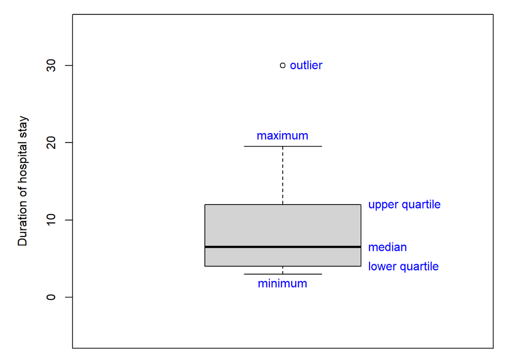

Figure 2.3: A box plot for our ten original observations of hospital stay duration.

Using our example (for example, by typing `boxplot(x_old)` into R), we obtain Figure 2.3. Note that the “maximum” here is $19.5$ rather than the actual maximum, $30$. This is because $30$ lies more than $1.5$ IQRs from the box and is therefore judged to be an outlier by R.[^2]

### 2.2.2 CDFs

For a random variable $X$, the **cumulative distribution function** is defined to be
$$F(x) = {\mathsf P}(X \leq x)$$
for all $x \in \mathbb{R}$. In other words, for any given real number $x$, this function gives us the probability that $X$ will be $\leq x$. In practice, we usually do not know $F(x)$ precisely.

However, if we observe a random sample from the distribution of $X$ then we can use these observations to estimate $F(x)$. We do this by defining a function $F_{n}(x)$ which gives the **proportion** of the observed sample $\leq x$. Then we can say $F(x) \approx F_n(x)$.

**Definition 2.6** The **sample cumulative distribution function (sample CDF)** of an observed sample $\{x_{1}, \ldots, x_{n}\}$ is the function defined by
$$F_n(x)=\frac{1}{n}\sum_{i=1}^n I[x_i \le x],$$
where $I[\cdot]$ is an indicator function,
$$I[x_i\le x]=\begin{cases}1 & \text{if } x_i\le x\\ 0 & \text{otherwise.}\end{cases}$$

In plain English,
$$F_n(x) = \frac{\text{number of observations that are $\leq x$}}{\text{total number of observations}}.$$

**Example 2.4 (hospital stay, continued)** Returning to the ordered data,
$$x_{(1)}, \ldots, x_{(10)} = 3, 3.5, 4, 5, 6, 7, 10, 12, 19.5, 30,$$
it is fairly easy to determine the sample CDF. For example,
$$\begin{eqnarray*}
F_{10}(4.5) & =& \frac{1}{10}\bigg(I[3 \leq 4.5] + I[3.5 \leq 4.5] + \ldots + I[30 \leq 4.5] \bigg) \\
& = & \frac{1}{10}\left(1 + 1 + 1 + 0 + \ldots + 0 \right) = \frac{3}{10}.
\end{eqnarray*}$$

This makes sense since only $3$ of the $10$ observations are less than or equal to $x = 4.5$. But we can do the same for any $x$, which gives us
$$F_{10}(x) = \begin{cases}
\frac{0}{10} & \text{if } x < 3,\\
\frac{1}{10} & \text{if } 3 \leq x < 3.5\\
\frac{2}{10} & \text{if } 3.5 \leq x < 4 \\
\frac{3}{10} & \text{if } 4 \leq x < 5 \\
\frac{4}{10} & \text{if } 5 \leq x < 6 \\
\frac{5}{10} & \text{if } 6 \leq x < 7 \\
\frac{6}{10} & \text{if } 7 \leq x < 10 \\
\frac{7}{10} & \text{if } 10 \leq x < 12 \\
\frac{8}{10} & \text{if } 12 \leq x < 19.5 \\
\frac{9}{10} & \text{if } 19.5 \leq x < 30 \\
\frac{10}{10} & \text{if } 30 \leq x
\end{cases}$$

Plotting this gives the graph below. We notice some general features of cumulative distribution functions: $F_{n}$ is non-decreasing and is bounded between $0$ and $1$.

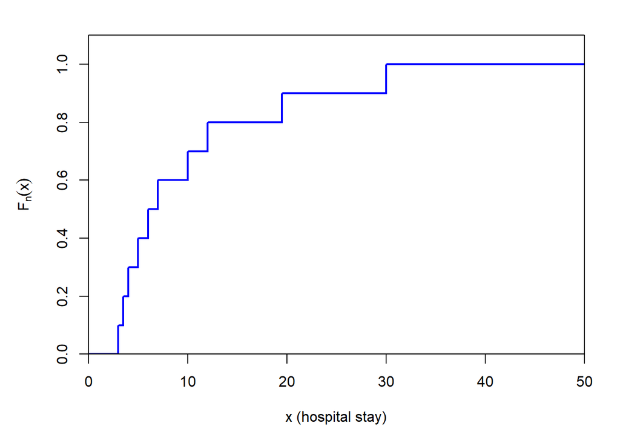

Figure 2.4: A graph of the sample cumulative distribution function, increasing from $0$ to $1$ in small steps at each observation.

$F_{n}(x)$ allows us to calculate approximate probabilities for $X$. For example, suppose that we want the probability that a hospital stay will be less than or equal to $15$ days. Figure 2.4 suggests
$${\mathsf P}(X \leq 15) = F(15) \approx F_{n}(15) = 80\%.$$

However, the sample CDF is less useful for identifying useful features of the distribution of $X$. In general, plots of cumulative distribution functions tend to look very similar for almost any sample: increasing from left to right, from $0$ to $1$. Therefore it can be quite difficult to assess important features such as location, spread and skew, or to compare two or more samples. We will see next that histograms are more useful for these purposes.

### 2.2.3 Histograms

We previously imagined probabilities as areas under a curve. Thinking this way again, $F(x) = {\mathsf P}(X \leq x) = {\mathsf P}(X \in (-\infty, x])$ is the area obtained by integrating a density function $f$ over an interval $(-\infty, x]$, so we have
$$F(x) = \int_{-\infty}^{x}f(u)du \qquad \Rightarrow \qquad f(x) = \frac{dF}{dx}(x).$$
So the curve that we typically imagine when visualising a distribution is given by the derivative of the cumulative distribution function. It might therefore be helpful to look at an approximation of $f(x)$ based on our sample, just as we used the sample CDF as an approximation for $F(x)$.

**Definition 2.7** Choose a collection of $N$ non-overlapping intervals, $I_j \subset \mathbb{R}$ with $j=1,\ldots,N$, that contain all of the observations in our sample. The **frequency distribution** for our sample is the corresponding list of frequencies
$$f_j=\sum_{i=1}^{n} I[x_i \in I_j] \quad \text{for } j=1,\ldots,N.$$

Each $f_{j}$ is just the number of observations that lie in interval $I_j$. To ensure the intervals are non-overlapping, we need an **endpoint convention**. For example, we might assume that an interval from $a$ to $b$ is the half-open interval $[a,b)$, which contains any observation $x_i$ such that $a\le x_i < b$.

**Example 2.5 (hospital stay, continued)** Recall the ordered version of our data set,
$$x_{(1)}, \ldots, x_{(10)} = 3, 3.5, 4, 5, 6, 7, 10, 12, 19.5, 30.$$
To obtain a frequency distribution, we are free to choose the intervals as we please. Let’s take $I_{1} = [0, 10)$, $I_{2} = [10, 20)$, $I_{3} = [20, 30)$, $I_{4} = [30, 40)$. Then we have
$$\begin{eqnarray*}
f_{1} & = & \sum_i I[x_i \in I_1]\\ & =& I[3 \in I_1] + I[3.5 \in I_1] + \ldots + I[30 \in I_1] \\ &=& 1 + 1 + \ldots + 0 = 6.\end{eqnarray*}$$
In other words, six observations lie in the interval from $0$ to $10$, so $f_{1} = 6$.

| frequency $f_j$ | interval $I_j$ |
| --- | --- |
| 6 | [0, 10) |
| 3 | [10, 20) |
| 0 | [20, 30) |
| 1 | [30, 40) |

We can use this to plot a **histogram**. For example, in R:

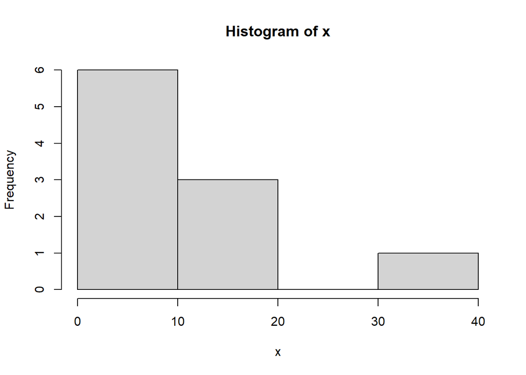

Figure 2.5: A histogram of our hospital stay data, showing the frequencies from our table.

```r
x <- c(3, 3.5, 4, 5, 6, 7, 10, 12, 19.5, 30)
hist(x, breaks = c(0, 10, 20, 30, 40), right = FALSE, freq = TRUE)
```

The `breaks` option allowed us to choose our intervals. Setting `right = FALSE` specified our endpoint convention that intervals are of the form $[a,b)$ and do not contain $b$. And `freq = TRUE` told R that the height of each bar should be the frequency.

Alternatively, we could plot densities, defined as
$$\frac{\text{proportion of observations in interval}}{\text{width of interval}} = \frac{f_j/n}{\text{width of } I_j}\;\;,$$
rather than frequencies by setting `freq = FALSE`. And we could let R choose the intervals and endpoint convention (by default, R chooses an endpoint convention based on intervals of the form $(a, b]$, rather than $[a, b)$) by simply leaving the other options blank.

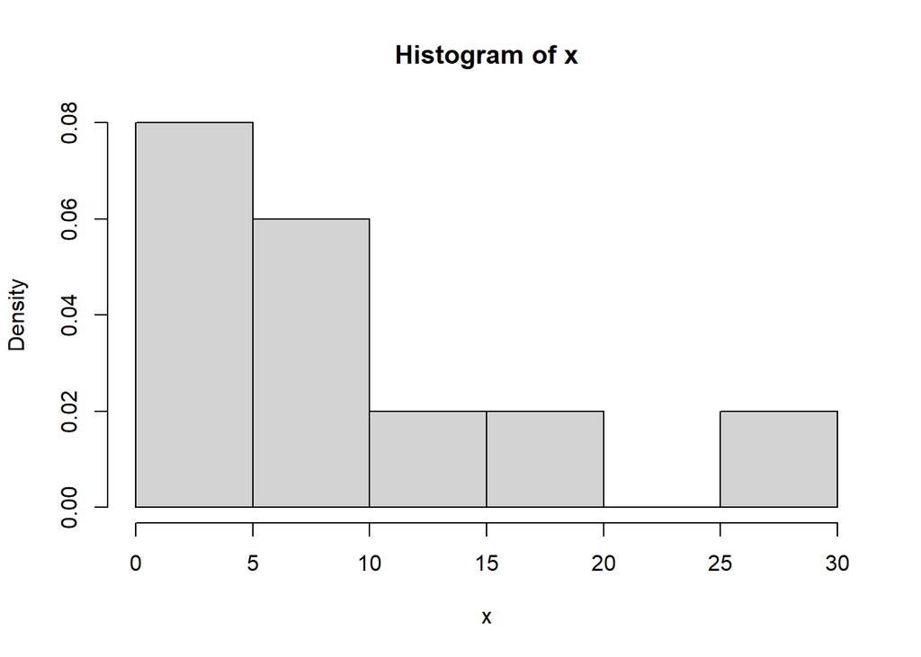

Figure 2.6: A histogram of our hospital stay data, showing densities for intervals chosen by R.

```r
hist(x, freq = FALSE)
```

We can now see the distribution of our sample a bit more clearly. Since we have plotted densities rather than frequencies, the **area** of each bar (which do not have to be equal width) is the proportion of our sample contained in the corresponding interval. For example, the interval from $15$ to $20$ only contains one observation, which is $10\%$ of our sample. The area of the corresponding bar is $0.02$ (the height) times $5$ (the width), which is $0.1 = 10\%$.

When plotting the densities, we can see why the histogram can be thought of as an approximation for $f(x)$. Remember that we said we can often think of probabilities as areas under the curve given by a function $f(x)$. Then, for example, we have
$$\begin{eqnarray*}
\int_{15}^{30}f(x) & = & {\mathsf P}(15 \leq X \leq 30)\\
& \approx & \text{(proportion between 15 and 30)}\\
& = & \text{(proportion between 15 and 20)} + \\
&& \text{(proportion between 20 and 25)} +\\
&& \text{(proportion between 25 and 30) }\\
& =& 0.1 + 0 + 0.1\\
&=& 0.2
\end{eqnarray*}$$
which is the combined area contained in the bars from $15$ to $20$, from $20$ to $25$, and from $25$ to $30$ in our histogram.

A major advantage of the histogram over the plot of the sample CDF is that we can easily see important characteristics of our sample in the histogram. We can immediately get a rough idea of the location, spread and skew of the data, and can spot potential outliers. In this example, the histogram suggests that hospital stays are skewed, and we can see that the stay of $30$ days lies far from the rest and is potentially an outlier.

**Warning:** We sometimes use intervals of unequal width, for example when data are very skewed (as they are here). When the intervals are **not** all of equal length, we should **plot densities, not frequencies**, otherwise we can end up with a very misleading graph.

## 2.3 Bivariate data

When we carry out a scientific study, it is rare that we observe only a single variable. We usually hope to determine the relationship between two or more random variables.

**Example 2.6 (hospital stay and time to death)** Duration of hospital stay might be used as a predictor of more serious outcomes. We might suspect that patients who stay in hospital longer will be in worse health generally and will therefore tend to die sooner. We can investigate this relationship by considering a **random vector**
$$(X, Y)$$
where $X$ denotes duration of hospital stay in days and $Y$ denotes time from surgery to death in years. Suppose that we observe a random sample
$$\begin{eqnarray*}
(x_{1}, y_{1}), \ldots, (x_{10}, y_{10}) & = & (3, 11), (3.5, 11), (4, 17), \\
& & (5, 13), (6, 14), (7,24), (10,16),\\
& & (12, 3), (19.5, 3), (30, 0).
\end{eqnarray*}$$

Data of this form is most easily summarised in a **scatter plot**.

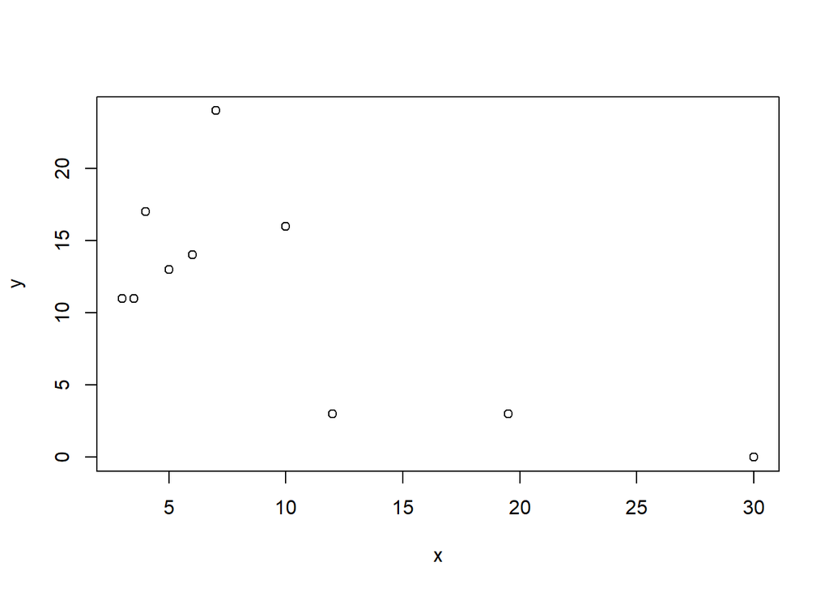

Figure 2.7: A scatter plot of our data, showing a vaguely negative relationship between hospital stay and survival time.

```r
x <- c(3, 3.5, 4, 5, 6, 7, 10, 12, 19.5, 30)
y <- c(11, 11, 17, 13, 14, 24, 16,  3,  3,  0)
plot(x, y)
```

There appears to be a negative relationship between $X$ and $Y$: patients who stay in hospital longer appear to die earlier. Can we quantify this?

**Definition 2.8** For data $(x_1,y_1),\ldots,(x_n,y_n)$, the **sample correlation** is
$$r_{xy}=\frac{\frac{1}{n-1}\sum_{i = 1}^{n} (x_i-\overline{x})(y_i-\overline{y})}{s_x s_y}$$
where $s_x$ and $s_y$ are the sample standard deviations of $\{x_1,\ldots,x_n\}$and $\{y_1,\ldots,y_n\}$.

It can be shown that $-1\le r_{xy} \le 1$. The closer $r_{xy}$ is to either $1$ or $-1$ the stronger the **linear** association between $X$ and $Y$ appears to be. If $r_{xy}=0$ then the data are **uncorrelated**, which means that there appears to be no linear association.

$r_{xy}=-1$ if and only if all points in the scatter plot lie on a straight line of negative slope. $r_{xy}=+1$ if and only if all points in the scatter plot lie on a straight line of positive slope.

`cor(x, y)` in R gives $r_{xy} \approx -0.7$ for our example, suggesting a fairly strong but negative linear relationship between hospital stay and time to death.

[^1]: R does not allow you to request Type 1 quantiles in the `boxplot()` function. This isn’t usually a big problem (it uses Type 7 quantiles, which typically won’t be much different). However, if you’re bothered by the difference between quantiles in your boxplots and in your numerical results then you might want to use the function `qboxplot()` instead (https://rdrr.io/cran/qboxplot/man/qboxplot.html), which allows you to produce boxplots based on your choice of quantile type.
[^2]: **Warning:** Don’t ignore or delete observations just because the boxplot function in R judges them to be outliers. The “plus or minus $1.5$ IQRs” rule is quite arbitrary and might not be appropriate for your data. In this example, $30$ days is a perfectly reasonable duration for a hospital stay and, depending on the type of surgery, is not necessarily an outlier.